# Car Seat Sales Analysis

Waleed Almousa

2024-03-20

## Variable selection with `Carseats` data set

The data set used for this project is the ‘Carseats’ data set from the ‘ISLR’ package. The goal of this project is to determine which variables are most impactful on the number of Car Seat sales, and then use these variables to create a linear regression model to predict car seat sales. The steps used to complete this are as follows:

1. Visualize/fitting: Created simple graphs and Linear regression model to visualize the data
2. Creating the model: Implemented Step wise variable selection method to develop and optimize a linear regression model of CarSeat sales
3. Interpreting the model: Provided an explanation of selected variables and what the coefficients of each respective variable represents
4. Evaluating the model: Performed Cross validation to find the out of sample MSE of the model
5. Discussion: Explained Potential model violations and how this model can be useful

Data is loaded in the following cell. For context, the first 6 rows of the data set are shown below. The dataset contains 400 observations and 11 variables.

```r
Carseats = ISLR::Carseats

# Further details on the dataset can be seen on the help page by running ?Carseats

str(Carseats)
```

```
## 'data.frame':    400 obs. of  11 variables:
##  $ Sales      : num  9.5 11.22 10.06 7.4 4.15 ...
##  $ CompPrice  : num  138 111 113 117 141 124 115 136 132 132 ...
##  $ Income     : num  73 48 35 100 64 113 105 81 110 113 ...
##  $ Advertising: num  11 16 10 4 3 13 0 15 0 0 ...
##  $ Population : num  276 260 269 466 340 501 45 425 108 131 ...
##  $ Price      : num  120 83 80 97 128 72 108 120 124 124 ...
##  $ ShelveLoc  : Factor w/ 3 levels "Bad","Good","Medium": 1 2 3 3 1 1 3 2 3 3 ...
##  $ Age        : num  42 65 59 55 38 78 71 67 76 76 ...
##  $ Education  : num  17 10 12 14 13 16 15 10 10 17 ...
##  $ Urban      : Factor w/ 2 levels "No","Yes": 2 2 2 2 2 1 2 2 1 1 ...
##  $ US         : Factor w/ 2 levels "No","Yes": 2 2 2 2 1 2 1 2 1 2 ...
```

```r
head(Carseats)
```

```
##   Sales CompPrice Income Advertising Population Price ShelveLoc Age Education
## 1  9.50       138     73          11        276   120       Bad  42        17
## 2 11.22       111     48          16        260    83      Good  65        10
## 3 10.06       113     35          10        269    80    Medium  59        12
## 4  7.40       117    100           4        466    97    Medium  55        14
## 5  4.15       141     64           3        340   128       Bad  38        13
## 6 10.81       124    113          13        501    72       Bad  78        16
##   Urban  US
## 1   Yes Yes
## 2   Yes Yes
## 3   Yes Yes
## 4   Yes Yes
## 5   Yes  No
## 6    No Yes
```

### Part 1) Visualizing/fitting

First, lets make some visualizations of the dataset to help set the stage for the rest of the analysis. Below are some plots that illustrate rough trends and the spread of the data.

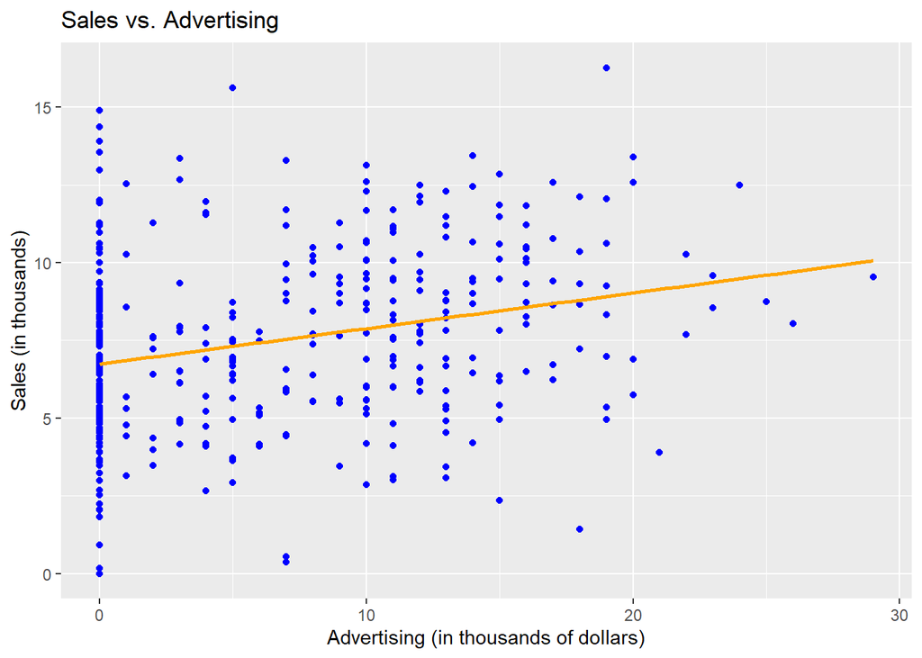

```r
ggplot(Carseats, aes(x = Advertising, y = Sales)) +
  geom_point(color = "blue") +
  geom_smooth(method = "lm", se = FALSE, color = "orange") +
  labs(title = "Sales vs. Advertising",
       x = "Advertising (in thousands of dollars)",
       y = "Sales (in thousands)")
```

As advertising for a product increases, product sales tend to increase as well.

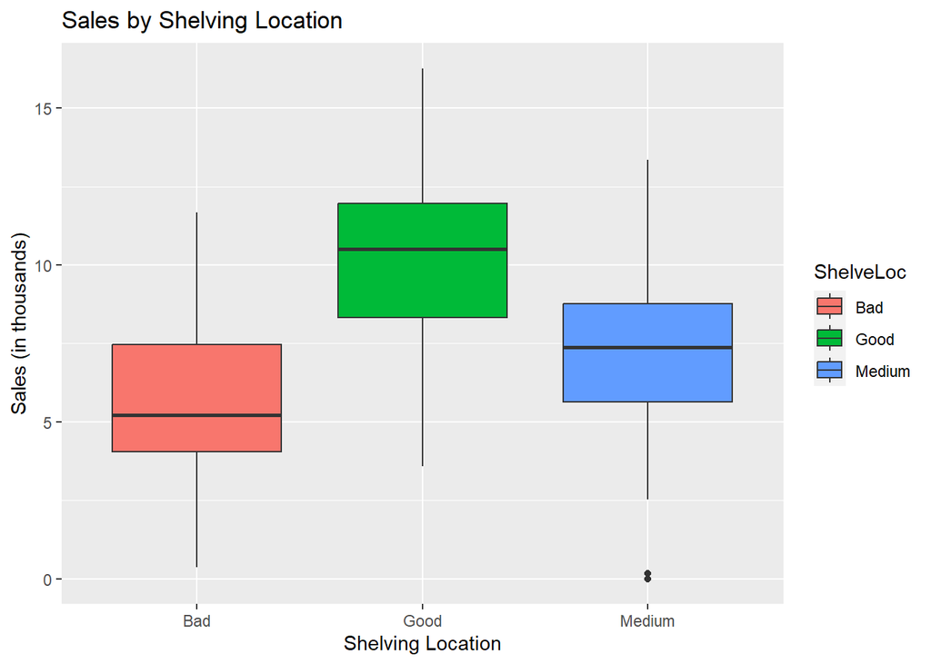

```r
ggplot(Carseats, aes(x = ShelveLoc, y = Sales, fill = ShelveLoc)) +
  geom_boxplot() +
  labs(title = "Sales by Shelving Location",
       x = "Shelving Location",
       y = "Sales (in thousands)")
```

Products with a shelving location categroized as “good” tend to have higher sales.

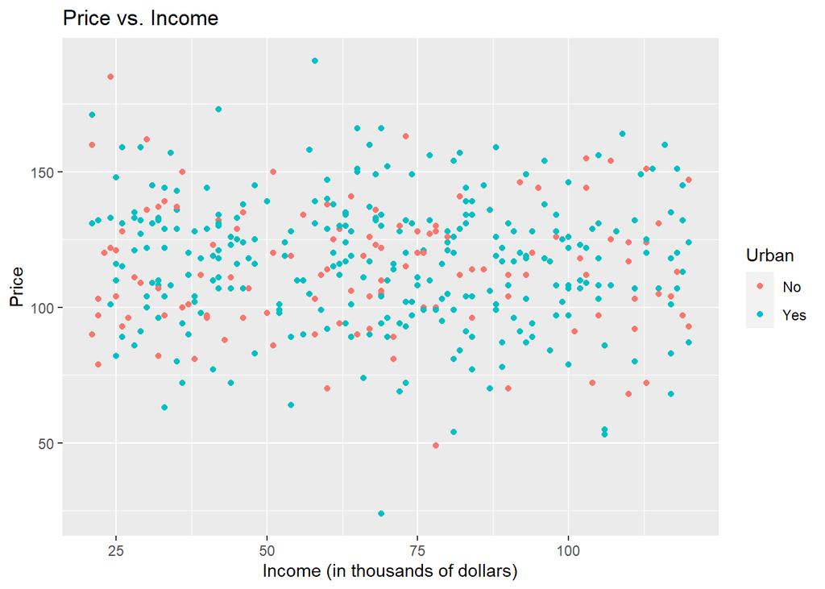

```r
ggplot(Carseats, aes(x = Income, y = Price, color = Urban)) +
  geom_point() +
  labs(title = "Price vs. Income",
       x = "Income (in thousands of dollars)",
       y = "Price")
```

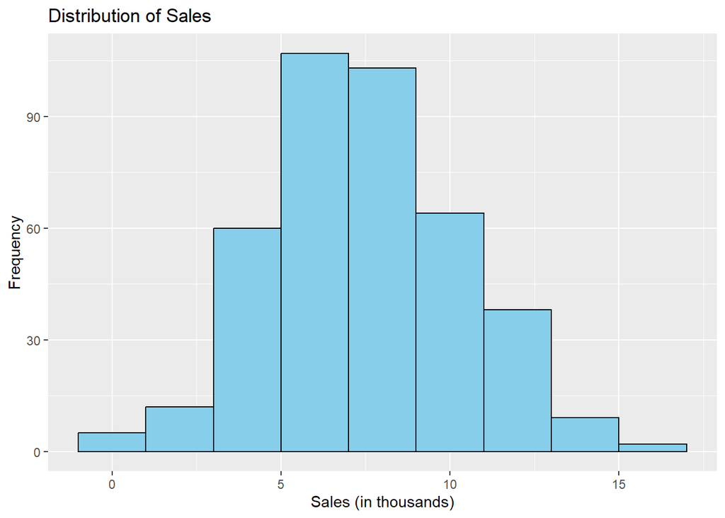

```r
ggplot(Carseats, aes(x = Sales)) +
  geom_histogram(binwidth = 2, fill = "skyblue", color = "black") +
  labs(title = "Distribution of Sales",
       x = "Sales (in thousands)",
       y = "Frequency")
```

### Part 2) Creating the model

I first ran a step wise variable selection algorithm to create a linear model. The algorithm began with a linear model containing ALL variables, and iteratively added/removed variables to improve the model until no further optimization can be made.

Here is the steps the initial stepwise model took:

```r
stepwise_model=step(lm(Sales ~ ., data = Carseats), direction = "both")
```

```
## Start:  AIC=26.82
## Sales ~ CompPrice + Income + Advertising + Population + Price +
##     ShelveLoc + Age + Education + Urban + US
##
##               Df Sum of Sq     RSS    AIC
## - Population   1      0.33  403.16  25.15
## - Education    1      1.19  404.02  26.00
## - Urban        1      1.23  404.06  26.04
## - US           1      1.57  404.40  26.38
## <none>                      402.83  26.82
## - Income       1     76.16  478.99  94.09
## - Advertising  1    127.14  529.97 134.54
## - Age          1    217.44  620.27 197.48
## - CompPrice    1    519.91  922.74 356.35
## - ShelveLoc    2   1053.20 1456.03 536.80
## - Price        1   1323.23 1726.06 606.85
##
## Step:  AIC=25.15
## Sales ~ CompPrice + Income + Advertising + Price + ShelveLoc +
##     Age + Education + Urban + US
##
##               Df Sum of Sq     RSS    AIC
## - Urban        1      1.15  404.31  24.29
## - Education    1      1.36  404.52  24.49
## - US           1      1.89  405.05  25.02
## <none>                      403.16  25.15
## + Population   1      0.33  402.83  26.82
## - Income       1     75.94  479.10  92.18
## - Advertising  1    145.38  548.54 146.32
## - Age          1    218.52  621.68 196.38
## - CompPrice    1    521.69  924.85 355.27
## - ShelveLoc    2   1053.18 1456.34 534.89
## - Price        1   1323.51 1726.67 605.00
##
## Step:  AIC=24.29
## Sales ~ CompPrice + Income + Advertising + Price + ShelveLoc +
##     Age + Education + US
##
##               Df Sum of Sq     RSS    AIC
## - Education    1      1.44  405.76  23.72
```

[output cut: 29 more lines]

```
## Sales ~ CompPrice + Income + Advertising + Price + ShelveLoc +
##     Age
##
##               Df Sum of Sq     RSS    AIC
## <none>                      407.39  23.32
## + US           1      1.63  405.76  23.72
## + Education    1      1.22  406.16  24.12
## + Urban        1      1.19  406.20  24.15
## + Population   1      0.72  406.67  24.62
## - Income       1     76.68  484.07  90.30
## - Age          1    219.12  626.51 193.48
## - Advertising  1    234.03  641.42 202.89
## - CompPrice    1    523.83  931.22 352.01
## - ShelveLoc    2   1055.51 1462.90 530.68
## - Price        1   1324.42 1731.81 600.18
```

Here is a summary of the initial stepwise model:

```r
summary(stepwise_model)
```

```
##
## Call:
## lm(formula = Sales ~ CompPrice + Income + Advertising + Price +
##     ShelveLoc + Age, data = Carseats)
##
## Residuals:
##     Min      1Q  Median      3Q     Max
## -2.7728 -0.6954  0.0282  0.6732  3.3292
##
## Coefficients:
##                  Estimate Std. Error t value Pr(>|t|)
## (Intercept)      5.475226   0.505005   10.84   <2e-16 ***
## CompPrice        0.092571   0.004123   22.45   <2e-16 ***
## Income           0.015785   0.001838    8.59   <2e-16 ***
## Advertising      0.115903   0.007724   15.01   <2e-16 ***
## Price           -0.095319   0.002670  -35.70   <2e-16 ***
## ShelveLocGood    4.835675   0.152499   31.71   <2e-16 ***
## ShelveLocMedium  1.951993   0.125375   15.57   <2e-16 ***
## Age             -0.046128   0.003177  -14.52   <2e-16 ***
## ---
## Signif. codes:  0 '***' 0.001 '**' 0.01 '*' 0.05 '.' 0.1 ' ' 1
##
## Residual standard error: 1.019 on 392 degrees of freedom
## Multiple R-squared:  0.872,  Adjusted R-squared:  0.8697
## F-statistic: 381.4 on 7 and 392 DF,  p-value: < 2.2e-16
```

This model had a RSE of 1.02 on 392 degrees of freedom. This is already extremely low, but I attempted to further improve the model below.

The below stepwise algorithm starts with ONLY the variables that were marked as statistically significant from the previous model, along with a few interaction terms. I ran the same algorithm as above to iteratively add/remove variables to improve the model.

```r
stepwise2 = step(lm(Sales ~ CompPrice+Income+Advertising+Price+ShelveLoc+Age+ CompPrice:Income+ CompPrice:Advertising+CompPrice:Price+CompPrice:ShelveLoc+CompPrice:Age+Advertising:Price+Advertising:Age, data = Carseats), direction = "both")
```

```
## Start:  AIC=23.71
## Sales ~ CompPrice + Income + Advertising + Price + ShelveLoc +
##     Age + CompPrice:Income + CompPrice:Advertising + CompPrice:Price +
##     CompPrice:ShelveLoc + CompPrice:Age + Advertising:Price +
##     Advertising:Age
##
##                         Df Sum of Sq    RSS    AIC
## - CompPrice:ShelveLoc    2    0.7957 392.59 20.523
## - CompPrice:Price        1    0.0522 391.85 21.765
## - Advertising:Age        1    0.5599 392.36 22.283
## - CompPrice:Age          1    0.8616 392.66 22.590
## - CompPrice:Advertising  1    1.4996 393.30 23.240
## <none>                               391.80 23.712
## - Advertising:Price      1    2.7257 394.52 24.485
## - CompPrice:Income       1    7.7186 399.52 29.515
##
## Step:  AIC=20.52
## Sales ~ CompPrice + Income + Advertising + Price + ShelveLoc +
##     Age + CompPrice:Income + CompPrice:Advertising + CompPrice:Price +
##     CompPrice:Age + Advertising:Price + Advertising:Age
##
##                         Df Sum of Sq     RSS    AIC
## - CompPrice:Price        1      0.09  392.69  18.62
## - Advertising:Age        1      0.53  393.12  19.06
## - CompPrice:Age          1      1.07  393.67  19.62
## - CompPrice:Advertising  1      1.41  394.00  19.96
## <none>                                392.59  20.52
## - Advertising:Price      1      2.55  395.14  21.11
## + CompPrice:ShelveLoc    2      0.80  391.80  23.71
## - CompPrice:Income       1      7.71  400.31  26.31
## - ShelveLoc              2   1034.26 1426.85 532.70
##
## Step:  AIC=18.62
## Sales ~ CompPrice + Income + Advertising + Price + ShelveLoc +
##     Age + CompPrice:Income + CompPrice:Advertising + CompPrice:Age +
##     Advertising:Price + Advertising:Age
##
##                         Df Sum of Sq     RSS    AIC
## - Advertising:Age        1      0.49  393.18  17.12
## - CompPrice:Age          1      1.07  393.76  17.71
```

[output cut: 58 more lines]

```
##     Age + CompPrice:Income
##
##                         Df Sum of Sq     RSS    AIC
## <none>                                397.57  15.56
## + Advertising:Price      1      1.75  395.82  15.80
## + CompPrice:Age          1      1.44  396.13  16.11
## + Advertising:Age        1      0.97  396.60  16.58
## + CompPrice:Price        1      0.16  397.41  17.41
## + CompPrice:Advertising  1      0.01  397.56  17.55
## + CompPrice:ShelveLoc    2      0.83  396.74  18.73
## - CompPrice:Income       1      9.81  407.39  23.32
## - Age                    1    217.98  615.55 188.42
## - Advertising            1    230.07  627.64 196.20
## - ShelveLoc              2   1054.80 1452.37 529.80
## - Price                  1   1323.84 1721.41 599.77
```

Summary of final model:

```r
# Final model:

summary(stepwise2)
```

```
##
## Call:
## lm(formula = Sales ~ CompPrice + Income + Advertising + Price +
##     ShelveLoc + Age + CompPrice:Income, data = Carseats)
##
## Residuals:
##     Min      1Q  Median      3Q     Max
## -2.8006 -0.6499 -0.0065  0.6734  3.3302
##
## Coefficients:
##                    Estimate Std. Error t value Pr(>|t|)
## (Intercept)       2.1320282  1.1863647   1.797  0.07309 .
## CompPrice         0.1196133  0.0096121  12.444  < 2e-16 ***
## Income            0.0636008  0.0154975   4.104 4.95e-05 ***
## Advertising       0.1150013  0.0076453  15.042  < 2e-16 ***
## Price            -0.0952982  0.0026411 -36.083  < 2e-16 ***
## ShelveLocGood     4.8300695  0.1508539  32.018  < 2e-16 ***
## ShelveLocMedium   1.9236595  0.1243487  15.470  < 2e-16 ***
## Age              -0.0460103  0.0031424 -14.642  < 2e-16 ***
## CompPrice:Income -0.0003868  0.0001245  -3.107  0.00203 **
## ---
## Signif. codes:  0 '***' 0.001 '**' 0.01 '*' 0.05 '.' 0.1 ' ' 1
##
## Residual standard error: 1.008 on 391 degrees of freedom
## Multiple R-squared:  0.8751, Adjusted R-squared:  0.8725
## F-statistic: 342.3 on 8 and 391 DF,  p-value: < 2.2e-16
```

I attempted to run the algorithm Again with non-linear variables to check if any of the features have a non-linear relationship with the number of Sales. There were no significant non-linear predictors, and thus I excluded this section from my project.

### Part 3) Interpreting Model

##### **Interpretation coefficients**

Below is an interpretation of each significant coefficient in the model.

The predictors that are most significant in predicting sales are: CompPrice, Income, Advertising, Price, ShelveLocGood, ShelveLocMedium, CompPrice:Income, and Age

Interpretation of coefficient:

GIVEN ALL OTHER VARIBLES ARE HELD CONSTANT for each of the following coeficient interpretations:

CompPrice: A one-unit increase in prices charged by competitors yields a .12 unit increase in sales

Income: A one-unit increase in community income level(in thousands) yields a .06 unit increase in sales

Advertising: A one unit increase in the local advertising budget(in thousand) yields a .12 unit increase in sales

Price: A one unit increase in the price of the car seat is associated with a .1 unit decrease in sales

ShelvLocGood: having a good shelving location is associated with an increase in sales of 4.83 units

ShelveLocMedium: having a medium shelving location is associated with a 1.92 unit increase in sales

Age: A one unit increase in the average age of the local population yields a .05 unit decrease in sales

CompPrice:Income: This interaction term suggests that the effect of compPrice on sales depends on income. A one unit increase in the product of compPrice and income is associated with a .00039 decrease in sales.

### Part 4) Evaluating the Model

To further evaluate the accuracy of the model, I performed Cross-validation to estimate the out-of-sample Mean Squared Error (MSE):

```r
set.seed(123) #Set seed for reproducability

cv_results <- cv.glm(Carseats, lm(formula(stepwise2), data=Carseats, x=T, y=T), K = 10)

cat("The out of sample MSE of the final model is: ", (cv_results$delta[1]))
```

```
## The out of sample MSE of the final model is:  1.04879
```

Below is a plot of the Q-Q Residuals of the model:

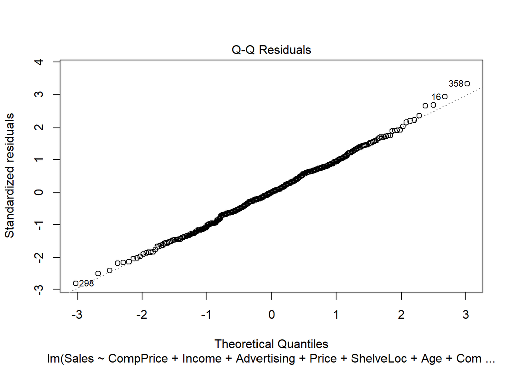

```r
plot(stepwise2, which = 2)
```

Statistical Summary of final model:

- MSE: 1.049
- R-Squared value: 0.88
- Adjusted R-Squared: 0.873
- RSE: 1 on 391 Degrees of freedom

### Discussion

#### **Potential Model violations**:

Step wise variable selection is done by adding/removing variables one at a time; this may lead to an unoptimized model, as some variable may become more important once others are removed.

An initial assumption that was made is that the effect of changes in predictors is constant regardless of the values of other predictors. I checked this assumption while fitting my model by implementing various interaction terms, one of which being in the final model. All other interaction terms were not significant enough to include in the final model.

#### **How can this model be useful?**

The coefficient of each respective variable give a clear representation of how each variable impacts car seat sales. This information can be utilized by companies to make adjustments to their product to increase sales. For example, a company can focus on putting their products in richer cities, increase the amount they put into advertising, and decrease their product price to increase Sales.

Though all of the adjustments suggested by the model may be intuitive, it gives a good illustration of exactly how much each factor impacts car seat sales. This model also demonstrates statistical proof to intuitive assumptions (such as the assumption that lower priced products tend to have relatively higher sales).